# Project 1-Customer Service Analysis

```python
#importing required libraries----------

import numpy as np
import pandas as pd
import matplotlib.pyplot as plt
import seaborn as sns
import datetime
data=pd.read_csv('project1_data.csv')
data
```

|  | Unique Key | Created Date | Closed Date | Agency | Agency Name | Complaint Type | Descriptor | Location Type | Incident Zip | Incident Address | ... | Bridge Highway Name | Bridge Highway Direction | Road Ramp | Bridge Highway Segment | Garage Lot Name | Ferry Direction | Ferry Terminal Name | Latitude | Longitude | Location |
| --- | --- | --- | --- | --- | --- | --- | --- | --- | --- | --- | --- | --- | --- | --- | --- | --- | --- | --- | --- | --- | --- |
| 0 | 32310363 | 12/31/2015 11:59:45 PM | 01-01-2016 00:55 | NYPD | New York City Police Department | Noise - Street/Sidewalk | Loud Music/Party | Street/Sidewalk | 10034.0 | 71 VERMILYEA AVENUE | ... | NaN | NaN | NaN | NaN | NaN | NaN | NaN | 40.865682 | -73.923501 | (40.86568153633767, -73.92350095571744) |
| 1 | 32309934 | 12/31/2015 11:59:44 PM | 01-01-2016 01:26 | NYPD | New York City Police Department | Blocked Driveway | No Access | Street/Sidewalk | 11105.0 | 27-07 23 AVENUE | ... | NaN | NaN | NaN | NaN | NaN | NaN | NaN | 40.775945 | -73.915094 | (40.775945312321085, -73.91509393898605) |
| 2 | 32309159 | 12/31/2015 11:59:29 PM | 01-01-2016 04:51 | NYPD | New York City Police Department | Blocked Driveway | No Access | Street/Sidewalk | 10458.0 | 2897 VALENTINE AVENUE | ... | NaN | NaN | NaN | NaN | NaN | NaN | NaN | 40.870325 | -73.888525 | (40.870324522111424, -73.88852464418646) |
| 3 | 32305098 | 12/31/2015 11:57:46 PM | 01-01-2016 07:43 | NYPD | New York City Police Department | Illegal Parking | Commercial Overnight Parking | Street/Sidewalk | 10461.0 | 2940 BAISLEY AVENUE | ... | NaN | NaN | NaN | NaN | NaN | NaN | NaN | 40.835994 | -73.828379 | (40.83599404683083, -73.82837939584206) |
| 4 | 32306529 | 12/31/2015 11:56:58 PM | 01-01-2016 03:24 | NYPD | New York City Police Department | Illegal Parking | Blocked Sidewalk | Street/Sidewalk | 11373.0 | 87-14 57 ROAD | ... | NaN | NaN | NaN | NaN | NaN | NaN | NaN | 40.733060 | -73.874170 | (40.733059618956815, -73.87416975810375) |
| ... | ... | ... | ... | ... | ... | ... | ... | ... | ... | ... | ... | ... | ... | ... | ... | ... | ... | ... | ... | ... | ... |
| 300693 | 30281872 | 03/29/2015 12:33:41 AM | NaN | NYPD | New York City Police Department | Noise - Commercial | Loud Music/Party | Club/Bar/Restaurant | NaN | CRESCENT AVENUE | ... | NaN | NaN | NaN | NaN | NaN | NaN | NaN | NaN | NaN | NaN |
| 300694 | 30281230 | 03/29/2015 12:33:28 AM | 03/29/2015 02:33:59 AM | NYPD | New York City Police Department | Blocked Driveway | Partial Access | Street/Sidewalk | 11418.0 | 100-17 87 AVENUE | ... | NaN | NaN | NaN | NaN | NaN | NaN | NaN | 40.694077 | -73.846087 | (40.69407728322387, -73.8460866160573) |
| 300695 | 30283424 | 03/29/2015 12:33:03 AM | 03/29/2015 03:40:20 AM | NYPD | New York City Police Department | Noise - Commercial | Loud Music/Party | Club/Bar/Restaurant | 11206.0 | 162 THROOP AVENUE | ... | NaN | NaN | NaN | NaN | NaN | NaN | NaN | 40.699590 | -73.944234 | (40.69959035300927, -73.94423377144169) |
| 300696 | 30280004 | 03/29/2015 12:33:02 AM | 03/29/2015 04:38:35 AM | NYPD | New York City Police Department | Noise - Commercial | Loud Music/Party | Club/Bar/Restaurant | 10461.0 | 3151 EAST TREMONT AVENUE | ... | NaN | NaN | NaN | NaN | NaN | NaN | NaN | 40.837708 | -73.834587 | (40.8377075854206, -73.83458731019586) |
| 300697 | 30281825 | 03/29/2015 12:33:01 AM | 03/29/2015 04:41:50 AM | NYPD | New York City Police Department | Noise - Commercial | Loud Music/Party | Store/Commercial | 10036.0 | 251 WEST 48 STREET | ... | NaN | NaN | NaN | NaN | NaN | NaN | NaN | 40.760583 | -73.985922 | (40.76058322950115, -73.98592204392392) |

300698 rows × 53 columns

```python
#dropping the unwanted columns-----------
data.drop(['Unique Key','Agency','Incident Zip','Incident Address','Incident Address','Street Name','Cross Street 1','Cross Street 2','Intersection Street 1','Intersection Street 2','Address Type','Landmark','Status','Due Date','Community Board','Borough','X Coordinate (State Plane)','Y Coordinate (State Plane)','Park Facility Name','Park Borough','School Name','School Number','School Region','School Code','School Phone Number','School Address','School City','School State','School Zip','School Not Found','School or Citywide Complaint','Vehicle Type','Taxi Company Borough','Taxi Pick Up Location','Bridge Highway Name','Bridge Highway Direction','Road Ramp','Bridge Highway Segment','Garage Lot Name','Ferry Direction','Ferry Terminal Name','Latitude','Longitude','Location','Resolution Action Updated Date'],axis=1,inplace=True)
data
```

|  | Created Date | Closed Date | Agency Name | Complaint Type | Descriptor | Location Type | City | Facility Type | Resolution Description |
| --- | --- | --- | --- | --- | --- | --- | --- | --- | --- |
| 0 | 12/31/2015 11:59:45 PM | 01-01-2016 00:55 | New York City Police Department | Noise - Street/Sidewalk | Loud Music/Party | Street/Sidewalk | NEW YORK | Precinct | The Police Department responded and upon arriv... |
| 1 | 12/31/2015 11:59:44 PM | 01-01-2016 01:26 | New York City Police Department | Blocked Driveway | No Access | Street/Sidewalk | ASTORIA | Precinct | The Police Department responded to the complai... |
| 2 | 12/31/2015 11:59:29 PM | 01-01-2016 04:51 | New York City Police Department | Blocked Driveway | No Access | Street/Sidewalk | BRONX | Precinct | The Police Department responded and upon arriv... |
| 3 | 12/31/2015 11:57:46 PM | 01-01-2016 07:43 | New York City Police Department | Illegal Parking | Commercial Overnight Parking | Street/Sidewalk | BRONX | Precinct | The Police Department responded to the complai... |
| 4 | 12/31/2015 11:56:58 PM | 01-01-2016 03:24 | New York City Police Department | Illegal Parking | Blocked Sidewalk | Street/Sidewalk | ELMHURST | Precinct | The Police Department responded and upon arriv... |
| ... | ... | ... | ... | ... | ... | ... | ... | ... | ... |
| 300693 | 03/29/2015 12:33:41 AM | NaN | New York City Police Department | Noise - Commercial | Loud Music/Party | Club/Bar/Restaurant | NaN | NaN | Your complaint has been forwarded to the New Y... |
| 300694 | 03/29/2015 12:33:28 AM | 03/29/2015 02:33:59 AM | New York City Police Department | Blocked Driveway | Partial Access | Street/Sidewalk | RICHMOND HILL | Precinct | The Police Department responded and upon arriv... |
| 300695 | 03/29/2015 12:33:03 AM | 03/29/2015 03:40:20 AM | New York City Police Department | Noise - Commercial | Loud Music/Party | Club/Bar/Restaurant | BROOKLYN | Precinct | The Police Department responded to the complai... |
| 300696 | 03/29/2015 12:33:02 AM | 03/29/2015 04:38:35 AM | New York City Police Department | Noise - Commercial | Loud Music/Party | Club/Bar/Restaurant | BRONX | Precinct | The Police Department responded to the complai... |
| 300697 | 03/29/2015 12:33:01 AM | 03/29/2015 04:41:50 AM | New York City Police Department | Noise - Commercial | Loud Music/Party | Store/Commercial | NEW YORK | Precinct | The Police Department responded to the complai... |

300698 rows × 9 columns

```python
#changing the datatype of created date and closed date from object type to datetime datatype-----------------
data['Created Date']=pd.to_datetime(data['Created Date'])
data['Closed Date']=pd.to_datetime(data['Closed Date'])
```

```python
#filling the the missing values using fillna method

data['Location Type'].fillna('No Location', inplace = True)
data['Descriptor'].fillna('No Discription', inplace = True)
data['City'].fillna('Not mentioned', inplace = True)
data['Facility Type'].fillna('Facility Type', inplace = True)
```

```python
# create a new column ‘Request_Closing_Time’ as the time elapsed between 'Creation Date and Closing Date'.---------------

data['Request_closing_time'] = data['Closed Date'] - data['Created Date']
data
```

|  | Created Date | Closed Date | Agency Name | Complaint Type | Descriptor | Location Type | City | Facility Type | Resolution Description | Request_closing_time |
| --- | --- | --- | --- | --- | --- | --- | --- | --- | --- | --- |
| 0 | 2015-12-31 23:59:45 | 2016-01-01 00:55:00 | New York City Police Department | Noise - Street/Sidewalk | Loud Music/Party | Street/Sidewalk | NEW YORK | Precinct | The Police Department responded and upon arriv... | 0 days 00:55:15 |
| 1 | 2015-12-31 23:59:44 | 2016-01-01 01:26:00 | New York City Police Department | Blocked Driveway | No Access | Street/Sidewalk | ASTORIA | Precinct | The Police Department responded to the complai... | 0 days 01:26:16 |
| 2 | 2015-12-31 23:59:29 | 2016-01-01 04:51:00 | New York City Police Department | Blocked Driveway | No Access | Street/Sidewalk | BRONX | Precinct | The Police Department responded and upon arriv... | 0 days 04:51:31 |
| 3 | 2015-12-31 23:57:46 | 2016-01-01 07:43:00 | New York City Police Department | Illegal Parking | Commercial Overnight Parking | Street/Sidewalk | BRONX | Precinct | The Police Department responded to the complai... | 0 days 07:45:14 |
| 4 | 2015-12-31 23:56:58 | 2016-01-01 03:24:00 | New York City Police Department | Illegal Parking | Blocked Sidewalk | Street/Sidewalk | ELMHURST | Precinct | The Police Department responded and upon arriv... | 0 days 03:27:02 |
| ... | ... | ... | ... | ... | ... | ... | ... | ... | ... | ... |
| 300693 | 2015-03-29 00:33:41 | NaT | New York City Police Department | Noise - Commercial | Loud Music/Party | Club/Bar/Restaurant | Not mentioned | Facility Type | Your complaint has been forwarded to the New Y... | NaT |
| 300694 | 2015-03-29 00:33:28 | 2015-03-29 02:33:59 | New York City Police Department | Blocked Driveway | Partial Access | Street/Sidewalk | RICHMOND HILL | Precinct | The Police Department responded and upon arriv... | 0 days 02:00:31 |
| 300695 | 2015-03-29 00:33:03 | 2015-03-29 03:40:20 | New York City Police Department | Noise - Commercial | Loud Music/Party | Club/Bar/Restaurant | BROOKLYN | Precinct | The Police Department responded to the complai... | 0 days 03:07:17 |
| 300696 | 2015-03-29 00:33:02 | 2015-03-29 04:38:35 | New York City Police Department | Noise - Commercial | Loud Music/Party | Club/Bar/Restaurant | BRONX | Precinct | The Police Department responded to the complai... | 0 days 04:05:33 |
| 300697 | 2015-03-29 00:33:01 | 2015-03-29 04:41:50 | New York City Police Department | Noise - Commercial | Loud Music/Party | Store/Commercial | NEW YORK | Precinct | The Police Department responded to the complai... | 0 days 04:08:49 |

300698 rows × 10 columns

# Visualizing some basic results that we can conclude from the data.

```python
# Measuring the frequency (occurence) of the different complaint-------------------

data_complaint=data['Complaint Type'].value_counts()
data_complaint = data_complaint.to_frame()
data_complaint = data_complaint.rename(columns={'Complaint Type':'Counts'})
data_complaint = data_complaint.reset_index()
data_complaint = data_complaint.rename(columns={'index':'Complaint Type'})
data_complaint.head(10)
```

|  | Complaint Type | Counts |
| --- | --- | --- |
| 0 | Blocked Driveway | 77044 |
| 1 | Illegal Parking | 75361 |
| 2 | Noise - Street/Sidewalk | 48612 |
| 3 | Noise - Commercial | 35577 |
| 4 | Derelict Vehicle | 17718 |
| 5 | Noise - Vehicle | 17083 |
| 6 | Animal Abuse | 7778 |
| 7 | Traffic | 4498 |
| 8 | Homeless Encampment | 4416 |
| 9 | Noise - Park | 4042 |

```python
# Evaluate the above in percentage----------------------

data_complaint['Percentage'] =np.around((data_complaint['Counts'] / data_complaint['Counts'].sum())*100,decimals=2)
data_complaint.head(10)
```

|  | Complaint Type | Counts | Percentage |
| --- | --- | --- | --- |
| 0 | Blocked Driveway | 77044 | 25.62 |
| 1 | Illegal Parking | 75361 | 25.06 |
| 2 | Noise - Street/Sidewalk | 48612 | 16.17 |
| 3 | Noise - Commercial | 35577 | 11.83 |
| 4 | Derelict Vehicle | 17718 | 5.89 |
| 5 | Noise - Vehicle | 17083 | 5.68 |
| 6 | Animal Abuse | 7778 | 2.59 |
| 7 | Traffic | 4498 | 1.50 |
| 8 | Homeless Encampment | 4416 | 1.47 |
| 9 | Noise - Park | 4042 | 1.34 |

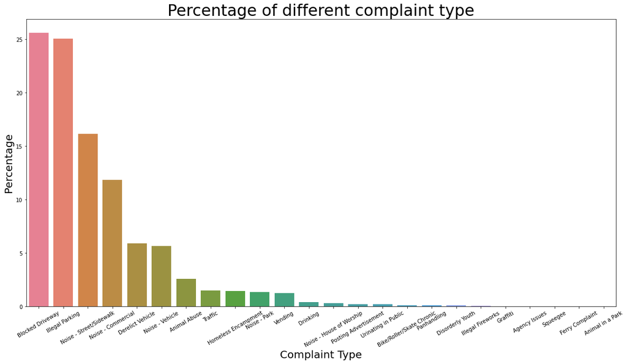

```python
#Visualization of the above dataset----------------------------

plt.figure(figsize=(20,10))
percentage=sns.barplot(x=data_complaint['Complaint Type'],y=data_complaint['Percentage'],palette='husl')
percentage.set_xticklabels(percentage.get_xticklabels(),rotation = 30)
plt.title('Percentage of different complaint type',fontsize=30)

percentage.set_xlabel('Complaint Type',fontsize=20)
percentage.set_ylabel('Percentage',fontsize=20)
```

From above table and graph it is clear that main complaint comes from 'Blocked Driveway','Illegal Parking' and noise from Street/Sidewalk or Commercial.

```python
# Applying the above procedure for Descriptor-------------------

data_descriptor=data['Descriptor'].value_counts()
data_descriptor= data_descriptor.to_frame()
data_descriptor = data_descriptor.rename(columns={'Descriptor':'Counts'})
data_descriptor = data_descriptor.reset_index()
data_descriptor= data_descriptor.rename(columns={'index':'Descriptor'})
data_descriptor['Percentage'] =np.around((data_descriptor['Counts'] / data_descriptor['Counts'].sum())*100,decimals=2)
data_descriptor = data_descriptor[(data_descriptor.Percentage) >= 2.0]
data_descriptor.head(10)
```

|  | Descriptor | Counts | Percentage |
| --- | --- | --- | --- |
| 0 | Loud Music/Party | 61430 | 20.43 |
| 1 | No Access | 56976 | 18.95 |
| 2 | Posted Parking Sign Violation | 22440 | 7.46 |
| 3 | Loud Talking | 21584 | 7.18 |
| 4 | Partial Access | 20068 | 6.67 |
| 5 | With License Plate | 17718 | 5.89 |
| 6 | Blocked Hydrant | 16081 | 5.35 |
| 7 | Commercial Overnight Parking | 12189 | 4.05 |
| 8 | Car/Truck Music | 11273 | 3.75 |
| 9 | Blocked Sidewalk | 11121 | 3.70 |

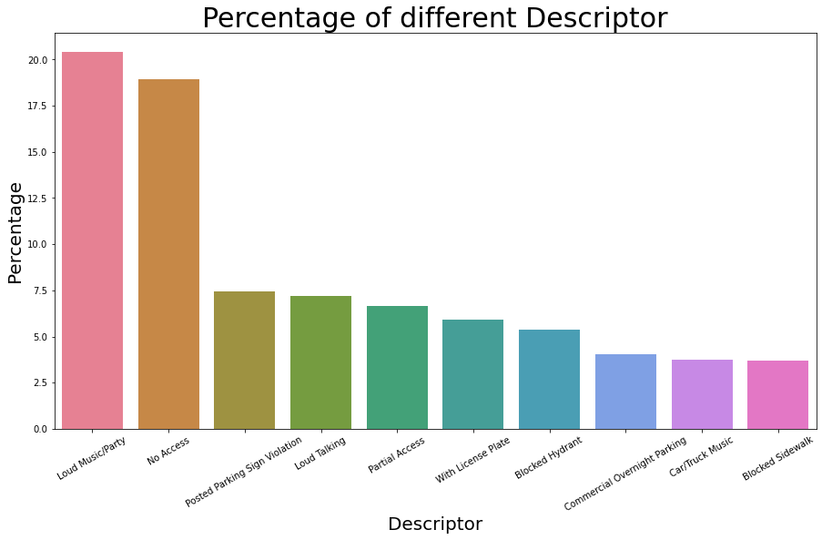

```python
#Visualization of the above dataset--------------------------
plt.figure(figsize=(15,8))
percentage=sns.barplot(x=data_descriptor['Descriptor'],y=data_descriptor['Percentage'],palette='husl')
percentage.set_xticklabels(percentage.get_xticklabels(),rotation = 30)
plt.title('Percentage of different Descriptor',fontsize=30)

percentage.set_xlabel('Descriptor',fontsize=20)
percentage.set_ylabel('Percentage',fontsize=20)
```

So it is obvious that the Loud Music/party causes the biggest problem for the citizens.

```python
# Applying the above procedure for Location Type -------------------


data_location=data['Location Type'].value_counts()
data_location=data_location.to_frame()
data_location=data_location.rename(columns={'Location Type':'Counts'})
data_location=data_location.reset_index()
data_location=data_location.rename(columns={'index':'Location Type'})
data_location['Percentage'] =np.around((data_location['Counts'] / data_location['Counts'].sum())*100,decimals=2)
data_location.head(10)
```

|  | Location Type | Counts | Percentage |
| --- | --- | --- | --- |
| 0 | Street/Sidewalk | 249299 | 82.91 |
| 1 | Store/Commercial | 20381 | 6.78 |
| 2 | Club/Bar/Restaurant | 17360 | 5.77 |
| 3 | Residential Building/House | 6960 | 2.31 |
| 4 | Park/Playground | 4773 | 1.59 |
| 5 | House of Worship | 929 | 0.31 |
| 6 | Residential Building | 227 | 0.08 |
| 7 | Highway | 215 | 0.07 |
| 8 | No Location | 131 | 0.04 |
| 9 | Parking Lot | 117 | 0.04 |

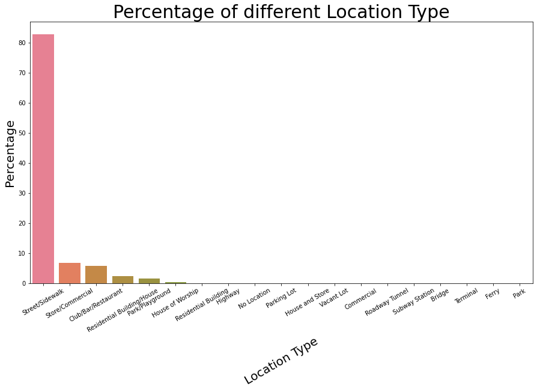

```python
#Visualization of the above dataset--------------------------

plt.figure(figsize=(15,8))
percentage=sns.barplot(x=data_location['Location Type'],y=data_location['Percentage'],palette='husl')
plt.title('Percentage of different Location Type',fontsize=30)
percentage.set_xlabel('Location Type',fontsize=20,rotation = 30)
percentage.set_ylabel('Percentage',fontsize=20)
percentage.set_xticklabels(percentage.get_xticklabels(),rotation = 30)
percentage
```

It seems most complaints occur at Street/Sidewalk.

```python
# Applying the above procedure for City -------------------


data_City=data['City'].value_counts()
data_City=data_City.to_frame()
data_City=data_City.rename(columns={'City':'Counts'})
data_City=data_City.reset_index()
data_City=data_City.rename(columns={'index':'City'})
data_City['Percentage'] =np.around((data_City['Counts'] / data_City['Counts'].sum())*100,decimals=2)
data_City = data_City[(data_City.Percentage) >= 2.0]

data_City
```

|  | City | Counts | Percentage |
| --- | --- | --- | --- |
| 0 | BROOKLYN | 98307 | 32.69 |
| 1 | NEW YORK | 65994 | 21.95 |
| 2 | BRONX | 40702 | 13.54 |
| 3 | STATEN ISLAND | 12343 | 4.10 |
| 4 | JAMAICA | 7296 | 2.43 |
| 5 | ASTORIA | 6330 | 2.11 |

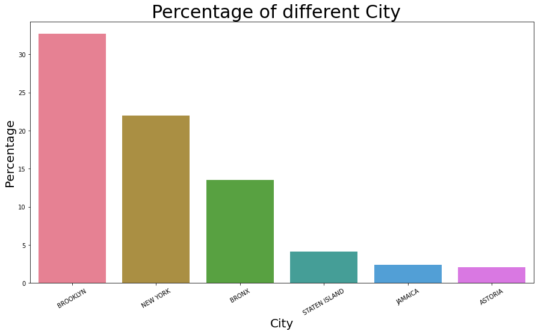

```python
#Visualization of the above dataset--------------------------

plt.figure(figsize=(15,8))
percentage=sns.barplot(x=data_City['City'],y=data_City['Percentage'],palette='husl')
percentage.set_xticklabels(percentage.get_xticklabels(),rotation=30)
plt.title('Percentage of different City  ',fontsize=30)

percentage.set_xlabel('City',fontsize=20)
percentage.set_ylabel('Percentage',fontsize=20)
```

Brooklyn faces the largest problems among all other cities.

# Order the complaint types based on the average ‘Request_Closing_Time’, grouping them for different locations

```python
CRL = data.groupby([ 'City','Complaint Type']).agg({'Request_closing_time': ['mean']})
CRL = CRL.rename(columns={'Request_closing_time':'Avg. Time(Given City, Complaint Type)'})
pd.set_option('display.max_rows', None)
pd.set_option('display.max_columns', None)
CRL
```

| City | Complaint Type | Avg. Time(Given City, Complaint Type) mean |
| --- | --- | --- |
| ARVERNE | Animal Abuse | 0 days 02:09:13.052631578 |
|  | Blocked Driveway | 0 days 02:31:33.485714285 |
|  | Derelict Vehicle | 0 days 02:58:05.592592592 |
|  | Disorderly Youth | 0 days 03:35:28.500000 |
|  | Drinking | 0 days 00:14:19 |
|  | Graffiti | 0 days 01:32:00 |
|  | Homeless Encampment | 0 days 01:48:53.250000 |
|  | Illegal Parking | 0 days 02:18:58.913793103 |
|  | Noise - Commercial | 0 days 02:17:14 |
|  | Noise - House of Worship | 0 days 01:33:43.909090909 |
|  | Noise - Park | 0 days 01:17:00 |
|  | Noise - Street/Sidewalk | 0 days 01:59:32.620689655 |
|  | Noise - Vehicle | 0 days 01:51:35.571428571 |
|  | Panhandling | 0 days 01:02:00 |
|  | Urinating in Public | 0 days 00:41:31 |
|  | Vending | 0 days 00:29:00 |
| ASTORIA | Animal Abuse | 0 days 05:00:00.608000 |
|  | Bike/Roller/Skate Chronic | 0 days 01:44:21.533333333 |
|  | Blocked Driveway | 0 days 04:48:58.024064171 |
|  | Derelict Vehicle | 0 days 09:41:21.299145299 |
|  | Disorderly Youth | 0 days 02:54:09.333333333 |
|  | Drinking | 0 days 04:43:20.714285714 |
|  | Graffiti | 0 days 14:05:42.250000 |
|  | Homeless Encampment | 0 days 04:55:03.312500 |
|  | Illegal Fireworks | 0 days 02:46:24.500000 |
|  | Illegal Parking | 0 days 04:50:00.207865168 |
|  | Noise - Commercial | 0 days 03:07:58.904872389 |
|  | Noise - House of Worship | 0 days 02:01:20 |
|  | Noise - Park | 0 days 02:59:42.393442622 |
|  | Noise - Street/Sidewalk | 0 days 03:27:04.189119170 |

[output cut: 752 more lines]

# statistical test

```python
import scipy.stats as stat
```

```python
#check the average time to solve a complaint--------------------
Complaint_AvgTime = data.groupby(['Complaint Type']).agg({'Request_closing_time':'mean'})
Complaint_AvgTime = Complaint_AvgTime.sort_values(['Request_closing_time']).reset_index()

Complaint_AvgTime
```

|  | Complaint Type | Request_closing_time |
| --- | --- | --- |
| 0 | Posting Advertisement | 0 days 01:58:32.891975308 |
| 1 | Illegal Fireworks | 0 days 02:45:40.101190476 |
| 2 | Noise - Commercial | 0 days 03:08:49.755979232 |
| 3 | Noise - House of Worship | 0 days 03:11:35.874058127 |
| 4 | Noise - Park | 0 days 03:24:38.636996519 |
| 5 | Noise - Street/Sidewalk | 0 days 03:26:42.806681088 |
| 6 | Traffic | 0 days 03:26:55.252001779 |
| 7 | Disorderly Youth | 0 days 03:33:30.902097902 |
| 8 | Noise - Vehicle | 0 days 03:35:20.376269594 |
| 9 | Urinating in Public | 0 days 03:37:35.991554054 |
| 10 | Bike/Roller/Skate Chronic | 0 days 03:45:59.264150943 |
| 11 | Drinking | 0 days 03:51:42.598431372 |
| 12 | Vending | 0 days 04:00:50.107246376 |
| 13 | Squeegee | 0 days 04:02:44.250000 |
| 14 | Homeless Encampment | 0 days 04:21:56.052536231 |
| 15 | Panhandling | 0 days 04:22:21.963934426 |
| 16 | Illegal Parking | 0 days 04:30:04.145454301 |
| 17 | Blocked Driveway | 0 days 04:44:27.258638198 |
| 18 | Animal Abuse | 0 days 05:12:47.677780638 |
| 19 | Agency Issues | 0 days 05:15:37.166666666 |
| 20 | Graffiti | 0 days 07:09:04.504424778 |
| 21 | Derelict Vehicle | 0 days 07:21:50.902717762 |
| 22 | Animal in a Park | 14 days 00:50:05 |
| 23 | Ferry Complaint | NaT |

from above it is clear that the Animal in park quite out of the range.

# One way ANOVA

First form sample for the test.Sample1 is drawn from Complaint_AvgTime and then find the rest_data and draw sample2 and 3 from it.

```python
sample1_anova = Complaint_AvgTime.sample(frac=1/3)
sample1_anova
```

|  | Complaint Type | Request_closing_time |
| --- | --- | --- |
| 6 | Traffic | 0 days 03:26:55.252001779 |
| 9 | Urinating in Public | 0 days 03:37:35.991554054 |
| 4 | Noise - Park | 0 days 03:24:38.636996519 |
| 1 | Illegal Fireworks | 0 days 02:45:40.101190476 |
| 11 | Drinking | 0 days 03:51:42.598431372 |
| 7 | Disorderly Youth | 0 days 03:33:30.902097902 |
| 17 | Blocked Driveway | 0 days 04:44:27.258638198 |
| 20 | Graffiti | 0 days 07:09:04.504424778 |

```python
rest_data = Complaint_AvgTime.drop(sample1_anova.index)
rest_data
```

|  | Complaint Type | Request_closing_time |
| --- | --- | --- |
| 0 | Posting Advertisement | 0 days 01:58:32.891975308 |
| 2 | Noise - Commercial | 0 days 03:08:49.755979232 |
| 3 | Noise - House of Worship | 0 days 03:11:35.874058127 |
| 5 | Noise - Street/Sidewalk | 0 days 03:26:42.806681088 |
| 8 | Noise - Vehicle | 0 days 03:35:20.376269594 |
| 10 | Bike/Roller/Skate Chronic | 0 days 03:45:59.264150943 |
| 12 | Vending | 0 days 04:00:50.107246376 |
| 13 | Squeegee | 0 days 04:02:44.250000 |
| 14 | Homeless Encampment | 0 days 04:21:56.052536231 |
| 15 | Panhandling | 0 days 04:22:21.963934426 |
| 16 | Illegal Parking | 0 days 04:30:04.145454301 |
| 18 | Animal Abuse | 0 days 05:12:47.677780638 |
| 19 | Agency Issues | 0 days 05:15:37.166666666 |
| 21 | Derelict Vehicle | 0 days 07:21:50.902717762 |
| 22 | Animal in a Park | 14 days 00:50:05 |
| 23 | Ferry Complaint | NaT |

```python
sample2_anova = rest_data.sample(frac=1/2)
sample2_anova
```

|  | Complaint Type | Request_closing_time |
| --- | --- | --- |
| 19 | Agency Issues | 0 days 05:15:37.166666666 |
| 13 | Squeegee | 0 days 04:02:44.250000 |
| 21 | Derelict Vehicle | 0 days 07:21:50.902717762 |
| 10 | Bike/Roller/Skate Chronic | 0 days 03:45:59.264150943 |
| 2 | Noise - Commercial | 0 days 03:08:49.755979232 |
| 12 | Vending | 0 days 04:00:50.107246376 |
| 3 | Noise - House of Worship | 0 days 03:11:35.874058127 |
| 15 | Panhandling | 0 days 04:22:21.963934426 |

```python
sample3_anova = rest_data.drop(sample2_anova.index)
sample3_anova
```

|  | Complaint Type | Request_closing_time |
| --- | --- | --- |
| 0 | Posting Advertisement | 0 days 01:58:32.891975308 |
| 5 | Noise - Street/Sidewalk | 0 days 03:26:42.806681088 |
| 8 | Noise - Vehicle | 0 days 03:35:20.376269594 |
| 14 | Homeless Encampment | 0 days 04:21:56.052536231 |
| 16 | Illegal Parking | 0 days 04:30:04.145454301 |
| 18 | Animal Abuse | 0 days 05:12:47.677780638 |
| 22 | Animal in a Park | 14 days 00:50:05 |
| 23 | Ferry Complaint | NaT |

```python
f_val,p_val = stat.f_oneway(sample1_anova['Request_closing_time'],sample2_anova['Request_closing_time'],sample3_anova['Request_closing_time'])
print('F-statistic is =',f_val)
print('p value is =',np.around(p_val,decimals=2))
```

```
F-statistic is = 0.9997053399242573
p value is = 0.38
```

```python
if (p_val<0.05):
    print('Null hypothesis is rejected since p value ({}) is less than 0.05'.format(np.around(p_val,decimals=2)))
else:
    print('Null hypothesis is accepted since p value ({}) is greater than 0.05'.format(np.around(p_val,decimals=2)))
```

```
Null hypothesis is accepted since p value (0.38) is greater than 0.05
```

Null Hypothesis states - there is no significant relationship among the average response time across complaint types

Alternate Hypothesis states - there is a significant relationship among the average response time across complaint types

# Are the type of complaint and location related

```python
#we use crosstab function to get more insight---------
City_Complaint = pd.crosstab(data['Complaint Type'],data['City'],margins=True, margins_name='Total')
#City_Complaint = pd.crosstab(df_cc['Complaint Type'],df_cc['City'])
City_Complaint.head(6)
```

| City Complaint Type | ARVERNE | ASTORIA | Astoria | BAYSIDE | BELLEROSE | BREEZY POINT | BRONX | BROOKLYN | CAMBRIA HEIGHTS | CENTRAL PARK | COLLEGE POINT | CORONA | EAST ELMHURST | ELMHURST | East Elmhurst | FAR ROCKAWAY | FLORAL PARK | FLUSHING | FOREST HILLS | FRESH MEADOWS | GLEN OAKS | HOLLIS | HOWARD BEACH | Howard Beach | JACKSON HEIGHTS | JAMAICA | KEW GARDENS | LITTLE NECK | LONG ISLAND CITY | … |
| --- | --- | --- | --- | --- | --- | --- | --- | --- | --- | --- | --- | --- | --- | --- | --- | --- | --- | --- | --- | --- | --- | --- | --- | --- | --- | --- | --- | --- | --- | --- |
| Agency Issues | 0 | 0 | 0 | 0 | 0 | 0 | 0 | 0 | 0 | 0 | 0 | 0 | 0 | 0 | 0 | 0 | 0 | 0 | 0 | 0 | 0 | 0 | 0 | 0 | 0 | 0 | 0 | 0 | 0 | … |
| Animal Abuse | 38 | 125 | 0 | 37 | 7 | 2 | 1415 | 2394 | 11 | 0 | 28 | 61 | 59 | 38 | 0 | 89 | 2 | 143 | 45 | 45 | 5 | 33 | 31 | 0 | 42 | 229 | 19 | 15 | 30 | … |
| Animal in a Park | 0 | 0 | 0 | 0 | 0 | 0 | 0 | 0 | 0 | 0 | 0 | 0 | 0 | 0 | 0 | 0 | 0 | 0 | 0 | 0 | 0 | 0 | 0 | 0 | 0 | 0 | 0 | 0 | 0 | … |
| Bike/Roller/Skate Chronic | 0 | 15 | 0 | 0 | 1 | 0 | 20 | 111 | 0 | 0 | 0 | 0 | 1 | 2 | 0 | 0 | 0 | 3 | 5 | 0 | 0 | 0 | 1 | 0 | 2 | 2 | 0 | 0 | 3 | … |
| Blocked Driveway | 35 | 2618 | 116 | 377 | 95 | 3 | 12755 | 28148 | 147 | 0 | 435 | 2761 | 1408 | 1446 | 0 | 284 | 20 | 2795 | 663 | 503 | 30 | 342 | 167 | 1 | 568 | 2818 | 313 | 121 | 772 | … |
| Derelict Vehicle | 27 | 351 | 12 | 198 | 89 | 3 | 1953 | 5181 | 115 | 0 | 184 | 57 | 113 | 78 | 1 | 187 | 56 | 440 | 52 | 291 | 49 | 143 | 138 | 0 | 29 | 954 | 14 | 61 | 195 | … |

# Chai square Contigency test

In order to find the relationship between complaint and city-----

```python
chai2, p_val, df, exp_frq = stat.chi2_contingency(City_Complaint)
```

```python
print('Chai square value =',chai2)
print('p-value is =',p_val)
```

```
Chai square value = 121788.33122567517
p-value is = 0.0
```

```python
if (p_val<0.05):
    print('Null hypothesis is rejected since p value ({}) is less than 0.05'.format(np.around(p_val,decimals=2)))
else:
    print('Null hypothesis is accepted since p value ({}) is greater than 0.05'.format(np.around(p_val,decimals=2)))
```

```
Null hypothesis is rejected since p value (0.0) is less than 0.05
```

Thus we may conclude that there is a relationship between the type of complaint or service requested and location.